# Analysis on Android Market: An Insight into Google Play Store App Data

## by Xiaoya Zhao

## Investigation Overview

The project aims to demonstrate the importance and value of data visualization techniques in the data analysis process in two parts: exploratory and explanatory visualizations. In specific, the dataset would be systematical explored, and findings such as properties, trends and relationships of the variables would be presented in a demonstrated slice.

## Dataset Overview

The original data of this study was provided by Lavanya Gupta in Kaggle. With the information about apps values (such as price, category,rating, size, and etc.), researcher are motivated to explore the enormous potential of the data and drive Android app-making businesses to success.

## Univariate Exploration

#### Which category of App occupy the most of the Android market?

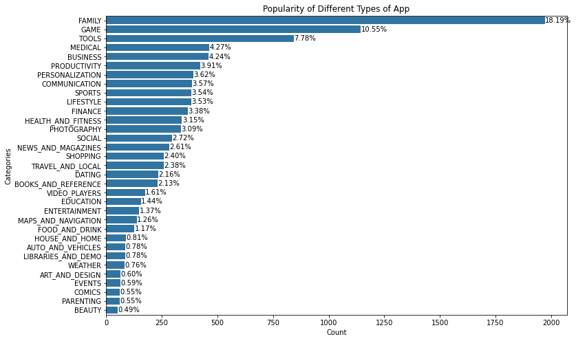

```python
# uniform the corlor
base_color = sb.color_palette()[0]

# set the order of the result
order = df.Category.value_counts().index

# barplot - the category and the Android market
plt.figure(figsize = [12,8])
sb.countplot(data = df, y = 'Category', color = base_color, order = order);

plt.title('Popularity of Different Types of App')
plt.xlabel('Count')
plt.ylabel('Categories')

# add the percentage
num_type = len(df.Category.value_counts())
for i in range (num_type):
    count = df.Category.value_counts()[i]
    plt.text(count+1, i, '{:.2f}%'.format(count * 100 /df.shape[0]), va = 'center')
```

#### How is the percentage of Free and Paid App in the Android market?

Most of Apps (92.62%) in the Android market are free to download.

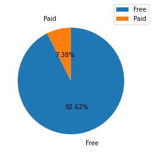

```python
# pie chart - percentage of Free or Paid App
# draw the pie chart in order

sorted_counts = df['Type'].value_counts()
plt.pie(sorted_counts, labels = sorted_counts.index, autopct='%.2f%%', startangle = 90,
        counterclock = False, pctdistance=0.5, labeldistance=1.2);
plt.legend(bbox_to_anchor=(0.8, 0.9));
```

#### How is the size of Apps distributed?

The log transformed histogram reveal that the App Size is bimodel, with peak at around 4MB and 28 MB.

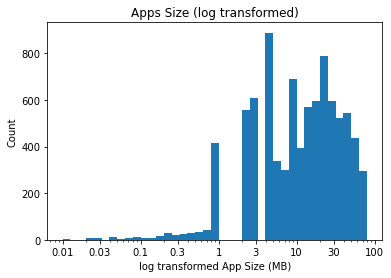

```python
# hist = distribution of App sizes

bins = 10 ** np.arange(-2, 2, 0.1)
ticks = [0.01,0.03,0.1,0.3,1,3,10,30,100]
labels = ['{}'.format(v) for v in ticks]
plt.hist(data = df, x = 'Size', bins = bins);
# the size (range from 0.01 to 100) should be log transformation
plt.xscale('log')
plt.xticks(ticks, labels);
plt.title('Apps Size (log transformed)')
plt.xlabel('log transformed App Size (MB)')
plt.ylabel('Count');
```

### Quality? -- How is the rating score distributed in Android market?

The rating score is strongly lefr skewed, with peak around 4.2.

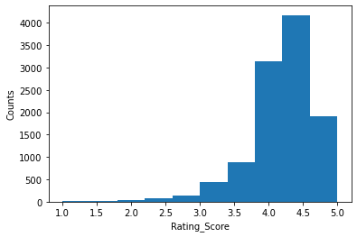

```python
# hist - distribution of rating score

plt.hist(data = df, x = 'Rating');
plt.xlabel('Rating_Score')
plt.ylabel('Counts');
```

#### Popularity? -- How is the number of installs distributed in Android market?

The bar graph demonstrates that the number of installs is left skewed, with the peak located between 1,000,000 and 5,000,000.

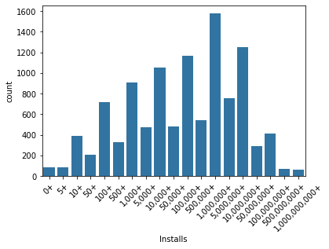

```python
# bar - distribution of number of install

# set Installs in order
install_order = ['0+','5+','10+','50+','100+','500+','1,000+','5,000+','10,000+','50,000+','100,000+','500,000+','1,000,000+','5,000,000+','10,000,000+','50,000,000+','100,000,000+','500,000,000+','1,000,000,000+']
install_order = pd.api.types.CategoricalDtype(categories = install_order, ordered = True)
df['Installs'] = df.Installs.astype(install_order)

sb.countplot(data = df, x = 'Installs',color = base_color);
plt.xticks(rotation = 45);
```

## Bivariate Exploration

The bivariate exploration would be applied to explore the relationship between app features and relevant user feedback

#### Are the paid Apps have higher mean rating score than free Apps?

The boxplot revealed that paid Apps had a slightly higher median rating score than that of free apps. This can be explained by many outliers below minmun score in Free Apps.

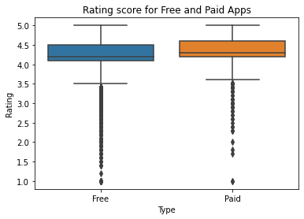

```python
# boxplot - type and rating
sb.boxplot(data = df, x = 'Type', y = 'Rating');

plt.title('Rating score for Free and Paid Apps');
```

#### What are the rating scores for the most three popoular App categories (Family, Game and Tools)?

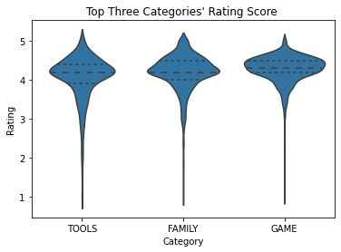

```python
# create a sub datefrome only with top three categories
df_sub = df.loc[df['Category'].isin(['FAMILY','GAME','TOOLS'])]

# violin plor - categories and score
sb.violinplot(data = df_sub, x = 'Category', y = 'Rating',
             inner = 'quartile',color = base_color)
plt.title("Top Three Categories' Rating Score ");
```

#### Is there a relationship between App size and rating score?

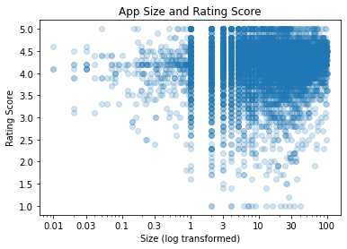

```python
# scatter plot - size and rating score
plt.scatter(data = df, x = 'Size', y = 'Rating',alpha = 0.2);

ticks = [0.01,0.03,0.1,0.3,1,3,10,30,100]
labels = ['{}'.format(v) for v in ticks]
plt.xscale('log')
plt.xticks(ticks,labels);
plt.title('App Size and Rating Score');
plt.xlabel('Size (log transformed)');
plt.ylabel('Rating Score');
```

## Multivariate Exploration

The multivariate exploration was conducted to reveal the relationship between rating_score, top-three categories and App size.

#### Is there any relationship between rating score, top-three categories and App size?

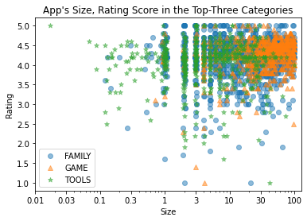

```python
# usting shape to distinguish the top-three categories
ttype_markers = [['FAMILY','o'],
                ['GAME','^'],
                ['TOOLS','*']]
df_sub2 = df_sub.sample(3000)
for ttype, marker in ttype_markers:
    plot_data = df_sub2.loc[df_sub['Category'] == ttype]
    sb.regplot(data = plot_data, x = 'Size', y = 'Rating',
              fit_reg = False, marker = marker, scatter_kws = {'alpha':0.5},
              x_jitter = 0.1);
    plt.xscale('log')
    ticks = [0.01,0.03,0.1,0.3,1,3,10,30,100]
    labels = ['{}'.format(v) for v in ticks]
    plt.xticks(ticks,labels)
plt.title("App's Size, Rating Score in the Top-Three Categories")
plt.legend(['FAMILY','GAME','TOOLS'])
```